# lab-6(faceting)

## Position scales

This code creates a faceted histogram of diamond prices, with each facet representing a different diamond color. The scales = “free_y” argument ensures that each facet has its own y-axis scale, allowing for a more detailed and accurate visualization of the distribution of diamond prices across different colors. This is particularly useful when the number of observations for each color varies significantly, as it prevents skewed visual representations due to a fixed y-axis range

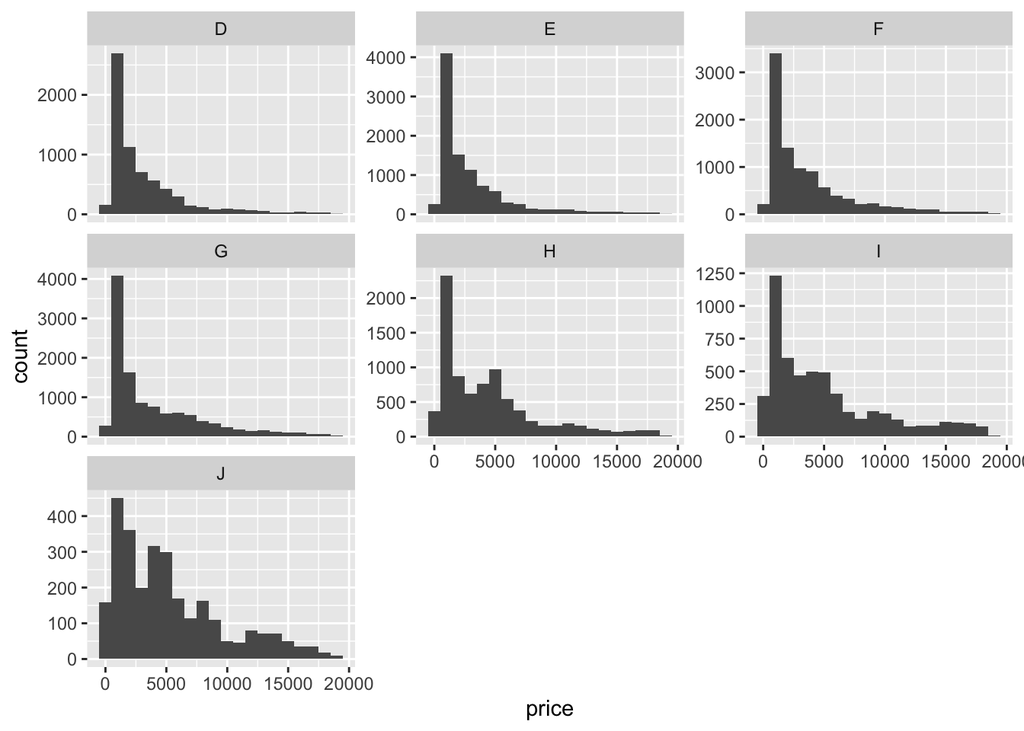

```r
p + facet_wrap(~color, scales = "free_y")
```

This code generates a scatter plot of city miles per gallon (cty) vs. highway miles per gallon (hwy) from the mpg dataset. The plot is divided into facets based on the number of cylinders (cyl), and each facet has its own x-axis and y-axis scales.

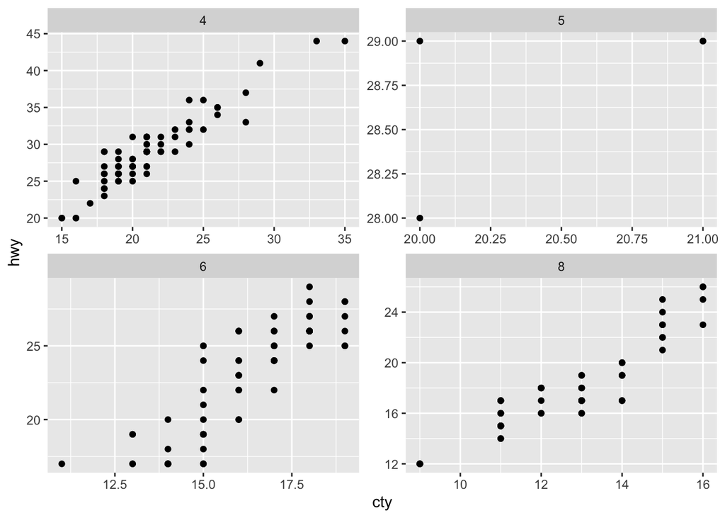

```r
ggplot(data = mpg, aes(cty, hwy)) + geom_point() + facet_wrap(~ cyl, scales = "free")
```

This code generates a scatter plot of city miles per gallon (cty) vs. highway miles per gallon (hwy) from the mpg dataset. The plot is divided into facets based on the number of cylinders (cyl), with each facet having its own x-axis scale (city mileage) but sharing the same y-axis scale (highway mileage).

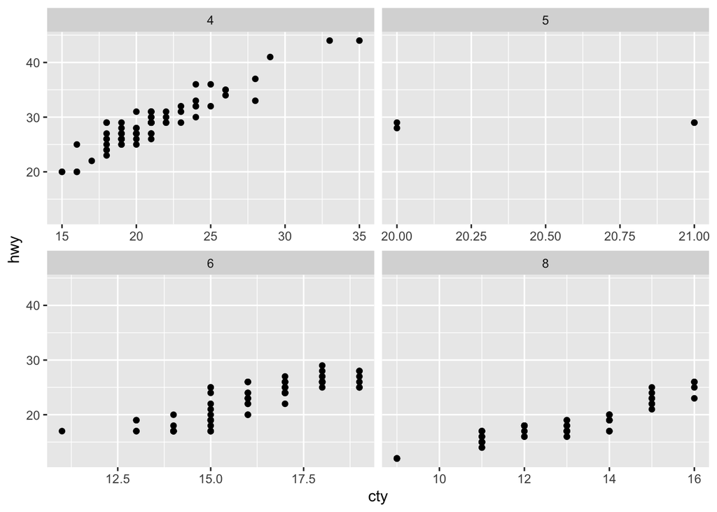

```r
ggplot(data = mpg, aes(cty, hwy)) + geom_point() + facet_wrap(~ cyl, scales = "free_x")
```

## Decorating facets

This code generates a faceted scatter plot of engine displacement (displ) vs. highway miles per gallon (hwy), divided by cylinder count (cyl). It then overlays additional red points representing cars with 6 cylinders on this plot, highlighting their distribution and allowing for a visual comparison with cars of other cylinder counts

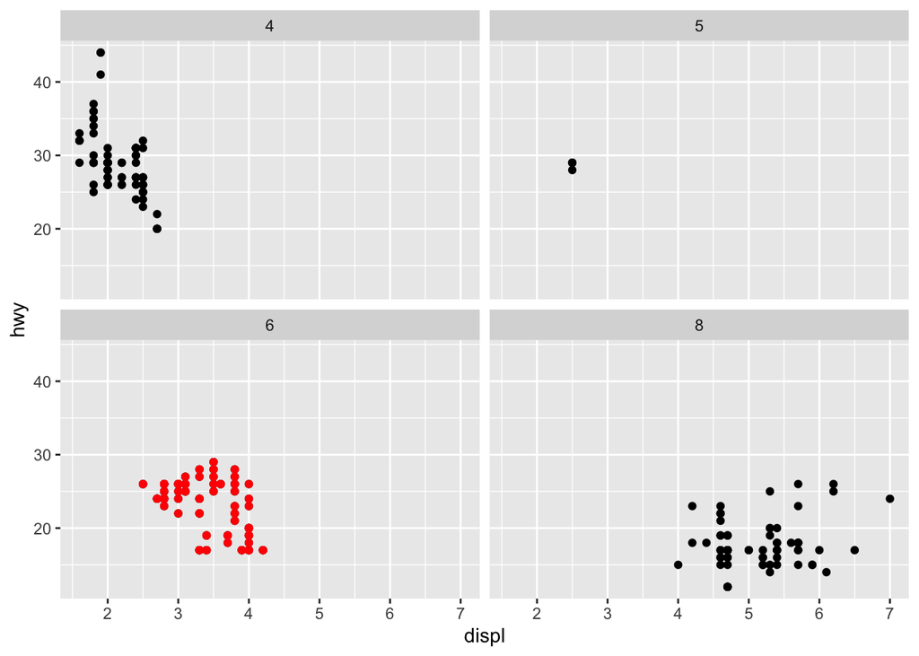

```r
p <- ggplot(data = mpg, aes(x = displ, y = hwy)) + geom_point()
q <- p + facet_wrap(~cyl)
cycl6 <- subset(mpg, cyl == 6)
q + geom_point(data = cycl6, color = "red")
```

## Faceting with abline and jitter

This code generates a faceted scatter plot of city miles per gallon versus highway miles per gallon using the mpg2 dataset, with each facet representing a different cylinder count. The plot includes a reference diagonal line (slope of 1) and jittered points to enhance visibility and reduce overplotting

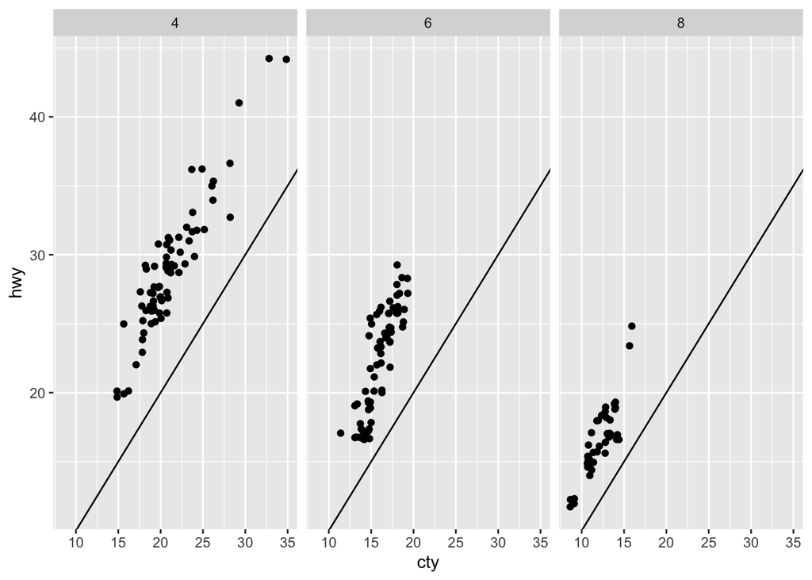

```r
p <- ggplot(mpg2, aes(cty, hwy)) +
 geom_abline() +
 geom_jitter()
p + facet_wrap(~cyl)
```

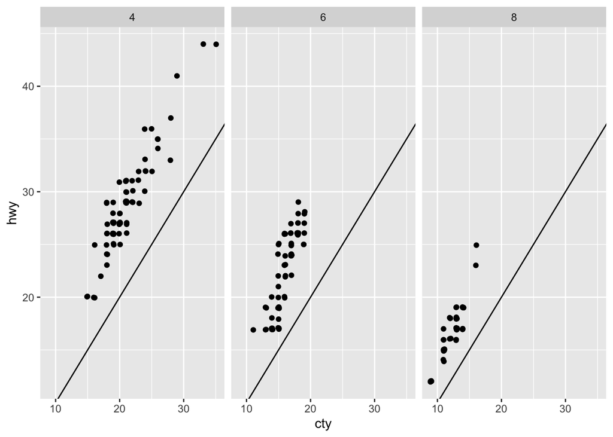

```r
p <- ggplot(mpg2, aes(cty, hwy)) +
 geom_abline() +
 geom_jitter(width = 0.1, height = 0.1)
p + facet_wrap(~cyl)
```

This code generates a faceted scatter plot of city miles per gallon versus highway miles per gallon from the mpg2 dataset. The plot includes a diagonal reference line and jittered points with specified horizontal and vertical jitter to reduce overplotting. Each facet corresponds to a different number of cylinders (cyl)

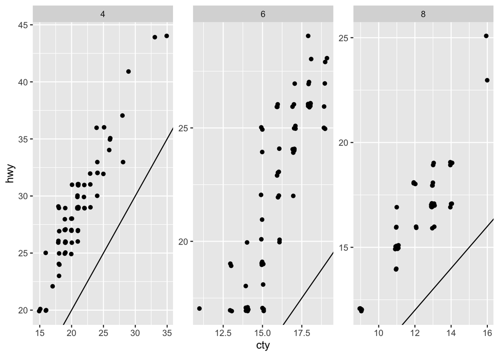

```r
p + facet_wrap(~cyl, scales = "free")
```

This code generates a faceted line plot of various economic variables over time from the economics_long dataset. Each facet represents a different variable and is displayed in a single column. The y-axis scales are adjusted independently for each facet to accurately represent the data, and lines connect data points to show trends over time, The trends in these variables vary, with some showing growth, fluctuations, or cyclical patterns

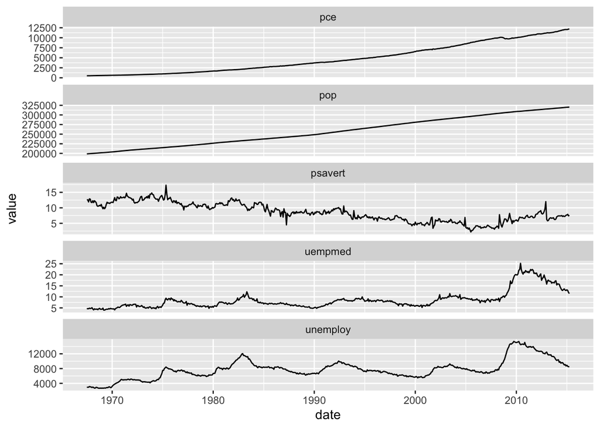

```r
ggplot(economics_long, aes(date, value)) +
 geom_line() +
 facet_wrap(~variable, scales = "free_y", ncol = 1)
```

## Facets with boxplot

This code converts the dose column in the ToothGrowth dataset from numeric to a factor, creates a copy of the modified dataset as df, and then displays the first six rows of this modified dataset.

```r
ToothGrowth$dose <- as.factor(ToothGrowth$dose)
df <- ToothGrowth
head(df)
```

```
##    len supp dose
## 1  4.2   VC  0.5
## 2 11.5   VC  0.5
## 3  7.3   VC  0.5
## 4  5.8   VC  0.5
## 5  6.4   VC  0.5
## 6 10.0   VC  0.5
```

## Creating a boxplot

This code creates and displays a boxplot of tooth length (len) against dose (dose) from the df dataset. Each dose level is represented as a separate boxplot, and the boxes are filled with different colors according to the dose levels. The box plot shows the distribution of “len” across different levels of “dose.” It reveals that “len” tends to increase with higher doses, and there are some outliers present in the data.

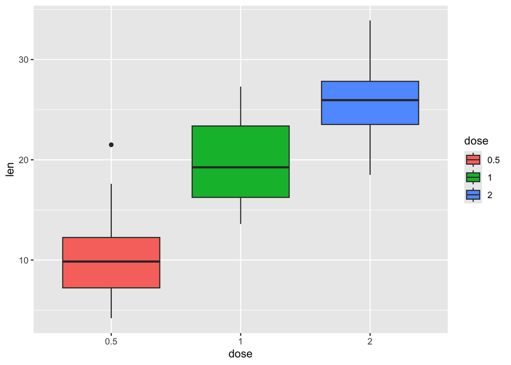

```r
bp <- ggplot(df, aes(x=dose, y=len, group=dose)) + geom_boxplot(aes(fill=dose))
print(bp)
```

The code adds faceting to the boxplot of tooth length versus dose. The facets are organized into rows based on the supp variable, with each row showing the boxplots for different supp levels. This provides a way to compare the distribution of tooth lengths for different doses separately for each supp category.

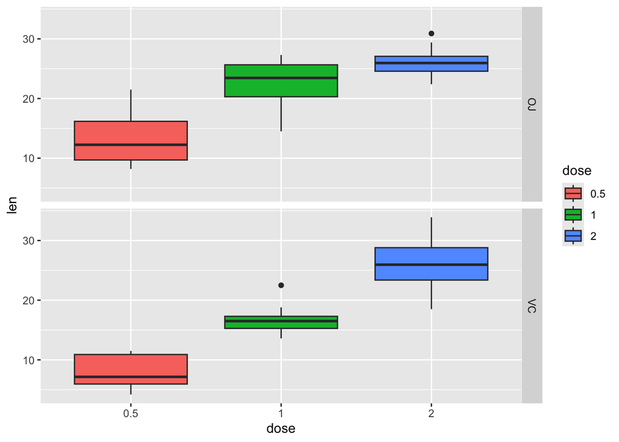

```r
bp + facet_grid(supp ~ .)
```

This code adds faceting to the boxplot of tooth length versus dose, organizing the facets into columns based on the supp variable. Each column represents a different level of supp, enabling a comparison of tooth length distributions across different doses for each supp category

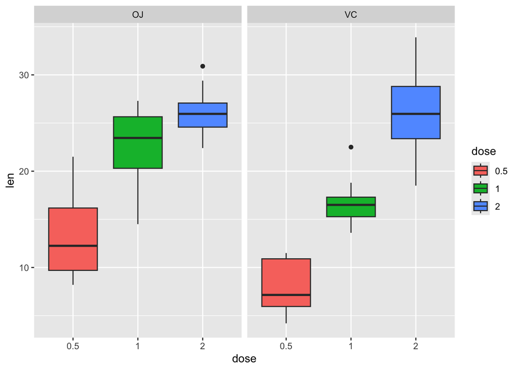

```r
bp + facet_grid(. ~ supp)
```

This code adds faceting to the boxplot of tooth length versus dose, arranging the facets into a grid based on the dose and supp variables. The grid layout allows for a comprehensive comparison of tooth length distributions for each combination of dose and supp.

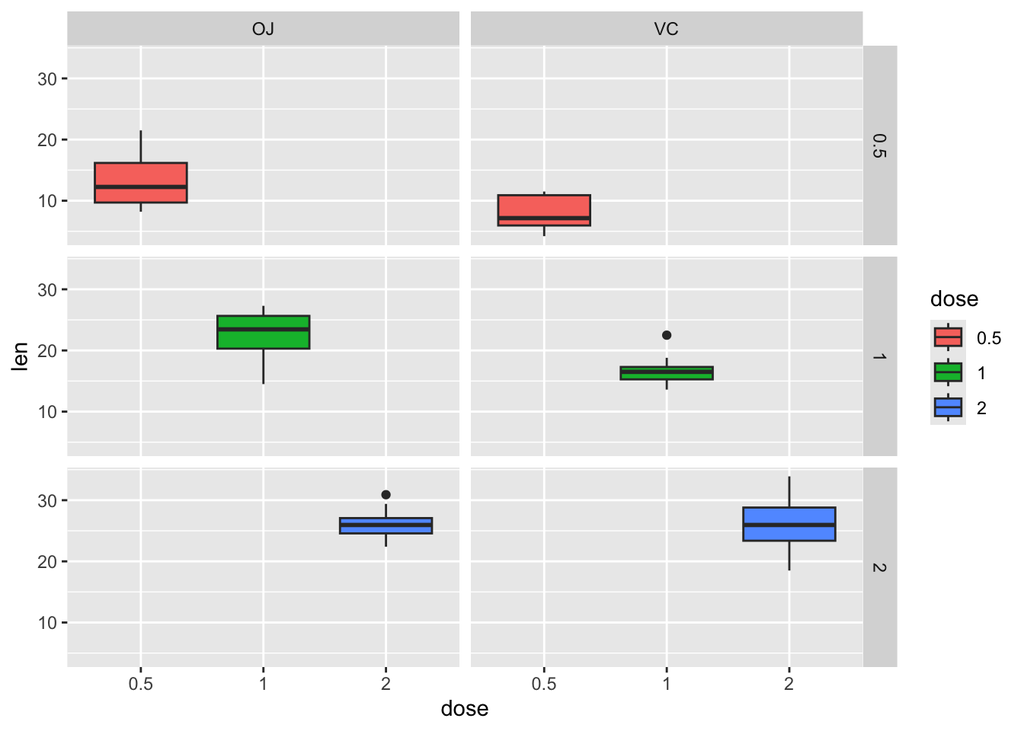

```r
bp + facet_grid(dose ~ supp)
```

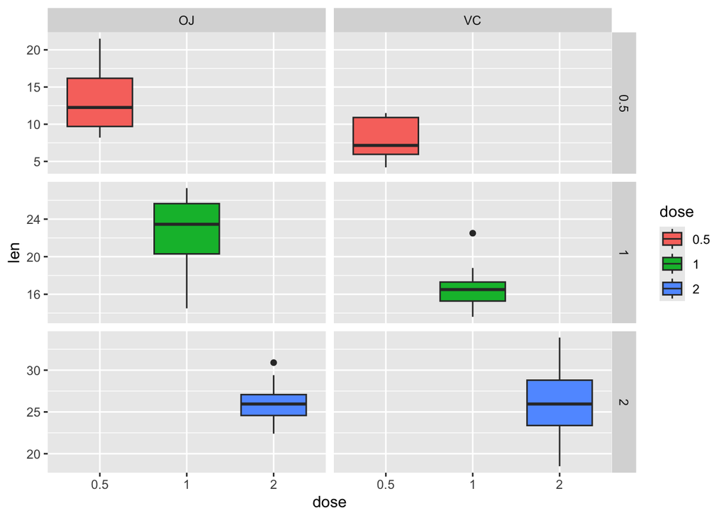

```r
bp + facet_grid(dose ~ supp, scales='free')
```

The code adds faceting to the existing plot (bp), creating a grid of subplots. Each subplot represents a combination of the dose and supp variables. The label_both labeller is used to show both the row (dose) and column (supp) variable names in the facet labels, making it easier to identify which combination of dose and supp each subplot corresponds to

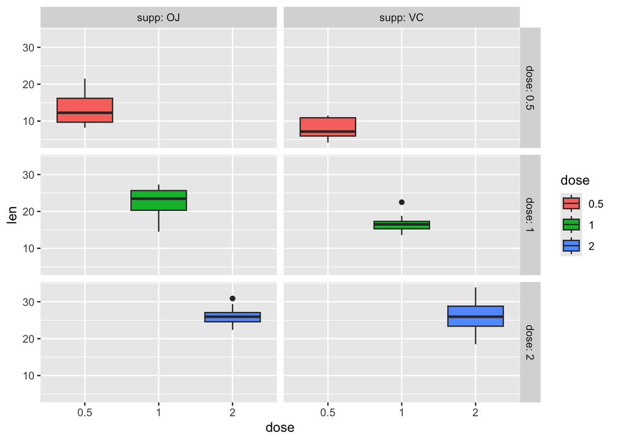

```r
bp + facet_grid(dose ~ supp, labeller=label_both)
```

## Grouping

### Default grouping in ggplot2

The code creates a plot using the mpg dataset that combines a scatter plot and a boxplot. The scatter plot shows individual data points with jitter to prevent overplotting, while the boxplot overlays a summary of the distribution of hwy values for each drv category, with no fill inside the boxes.

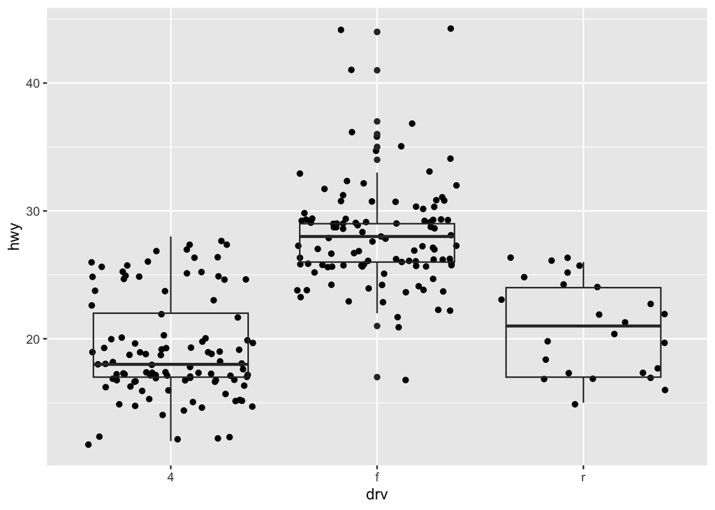

```r
p1 <- ggplot(mpg, aes(drv, hwy)) +
 geom_jitter() +
 stat_boxplot(fill = NA)
p1
```

## making the new dataset

this code creates a data frame with specified values for three columns, where x and z are categorical variables and y is a numerical variable

```r
df <- data.frame(x = c("a", "a", "a", "a", "b", "b", "b", "b"),
 y = c(1, 2, 3, 4, 4, 3, 2, 1),
 z = c("A", "A", "B", "B", "B", "B", "A", "A"))
df
```

```
##   x y z
## 1 a 1 A
## 2 a 2 A
## 3 a 3 B
## 4 a 4 B
## 5 b 4 B
## 6 b 3 B
## 7 b 2 A
## 8 b 1 A
```

the plot display a scatter plot with points connected by lines in the order they are listed in the data frame, effectively showing the progression or sequence of the data.

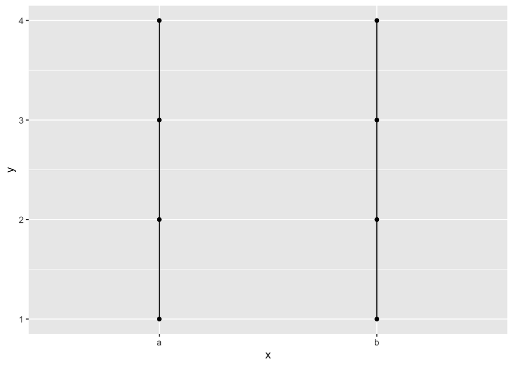

```r
ggplot(df, aes(x, y)) +
 geom_point() +
 geom_path()
```

the plot display scatter plot with a single line connecting all the points in the order they are listed in the data frame, indicating the sequence of the data as a continuous path

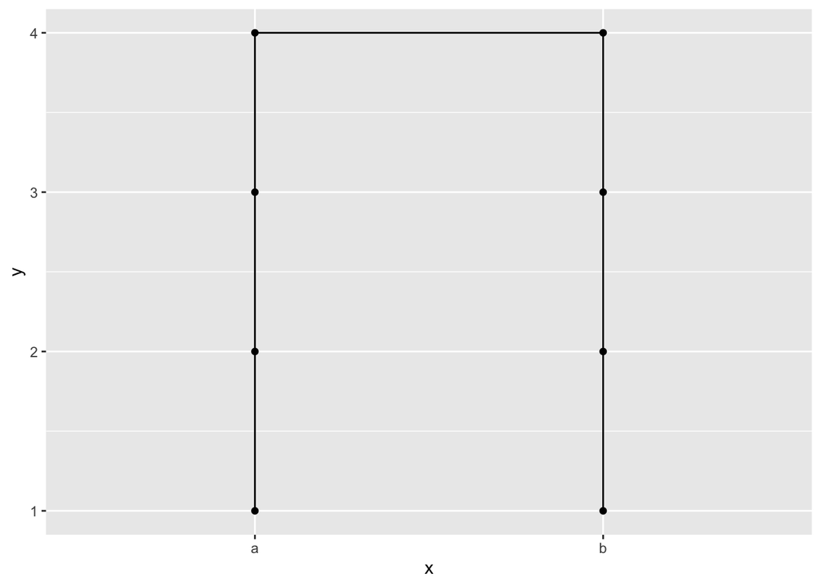

```r
ggplot(df, aes(x, y)) +
 geom_point() +
 geom_path(aes(group = 10))
```